# MIC analysis of Methicillin-resistant Staphylococcus epidermidis

Olivier Restif, with data from Jesper Larsen

21/04/2022

Last updated: 2022-05-12

# Data description

Number of samples: 138

```
## # A tibble: 3 × 2
##   Genotype_EMH  Samples
##   <chr>           <int>
## 1 Resistant 2        77
## 2 Susceptible 2      56
## 3 Susceptible 3       5
```

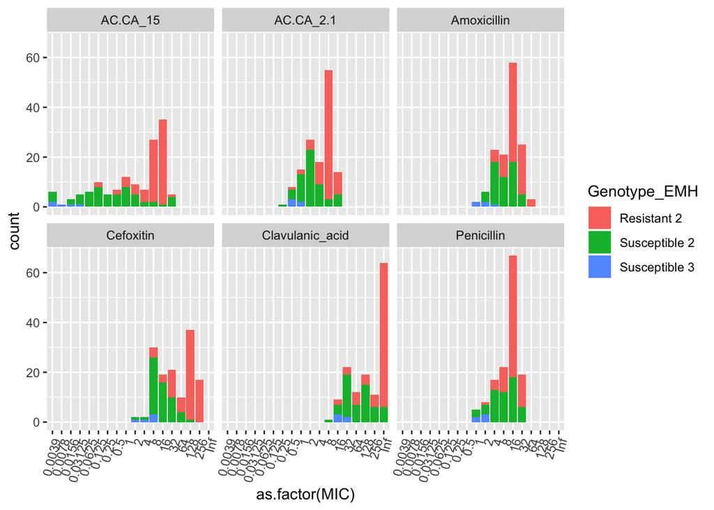

Pairwise correlations. Values show log2(MIC).

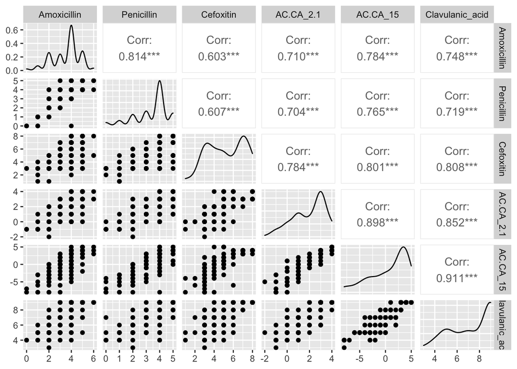

# Mixture models

## AC/CA (15)

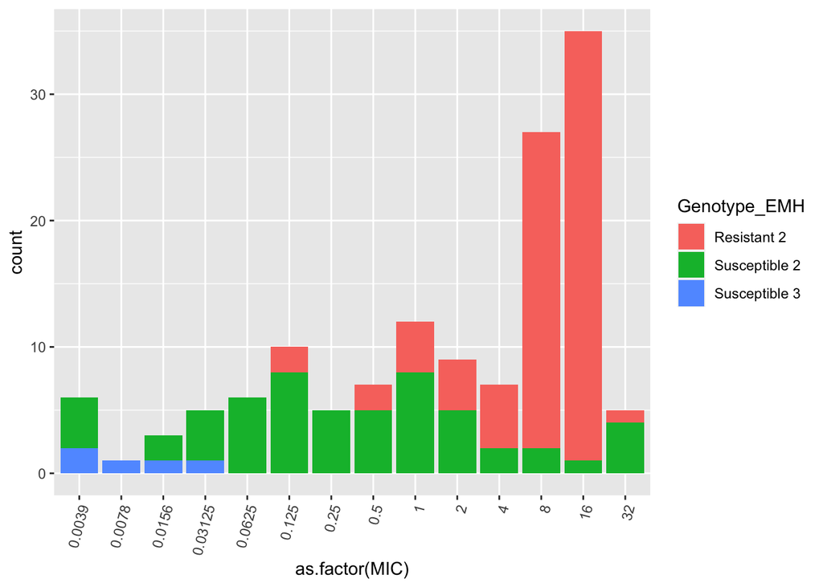

```
##   k split   cut.off WT NWT     N.mis
## 1 2     1 5.6568542 71  67  8.594866
## 2 3     1 0.7071068 43  95 13.297053
## 3 3     2 5.6568542 71  67  4.559110
```

Proposed ECOFF for AC/CA 15: 5.66.

- The 71 isolates with MIC $\leq 4$ are labelled “susceptible”.
- The 67 isolates with MIC $\geq 8$ are labelled “resistant”.

Predicted distribution of susceptible (S) and resistant (R) isolates from the model, with actual data shown in grey:

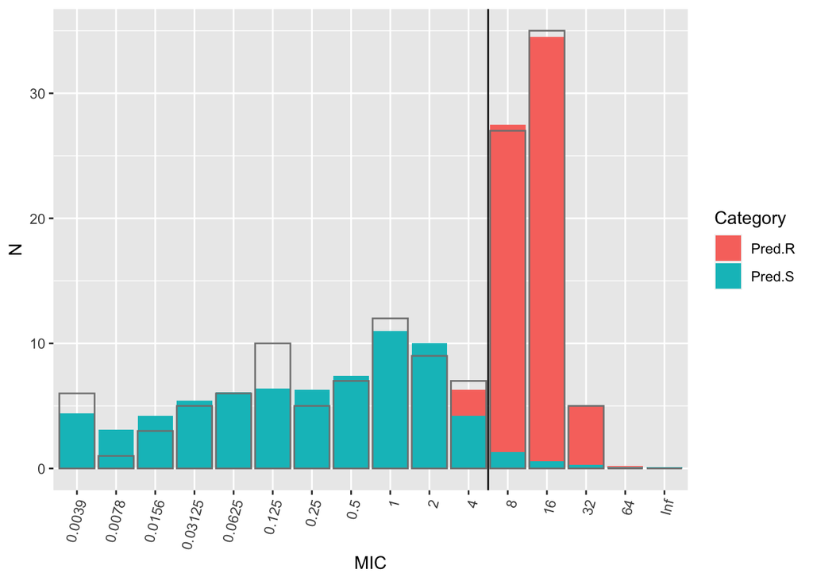

## AC/CA (2:1 in MHB)

Here we only report the MIC for the second drug, e.g. 4 for “8/4”.

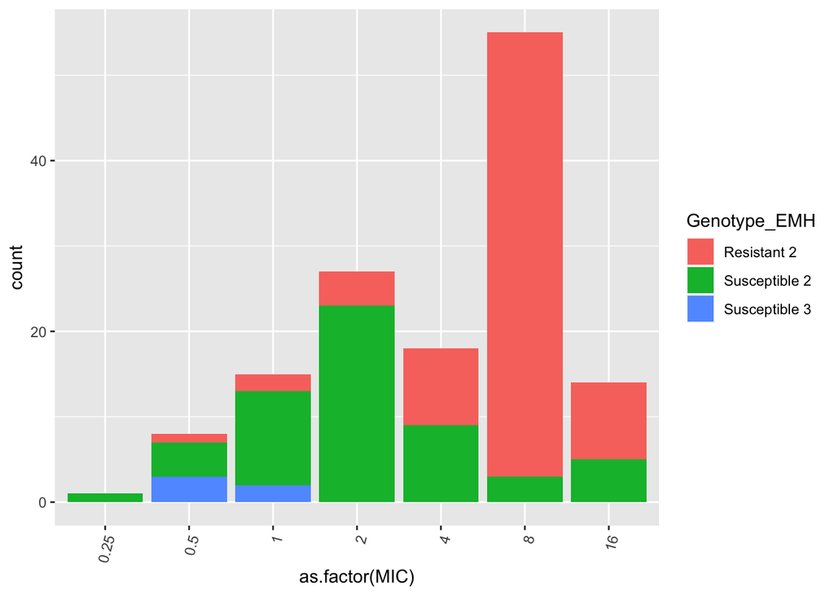

```
##   k split   cut.off WT NWT    N.mis
## 1 2     1 5.6568542 69  69 7.331916
## 2 3     1 0.7071068  9 129 4.132071
## 3 3     2 5.6568542 69  69 3.974233
```

Proposed ECOFF for “AC/CA (2:1 in MHB)”: 11.3/5.65.

- The 69 isolates with MIC $\leq 4$ are labelled “susceptible”.
- The 69 isolates with MIC $\geq 8$ are labelled “resistant”.

Predicted distribution of susceptible (S) and resistant (R) isolates from the model, with actual data shown in grey:

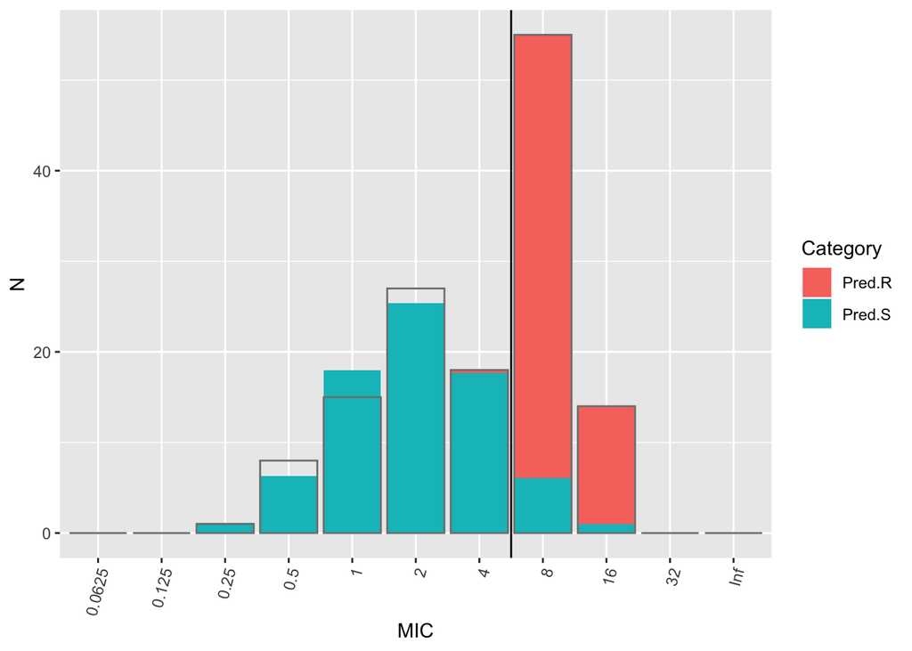

## Amoxicillin

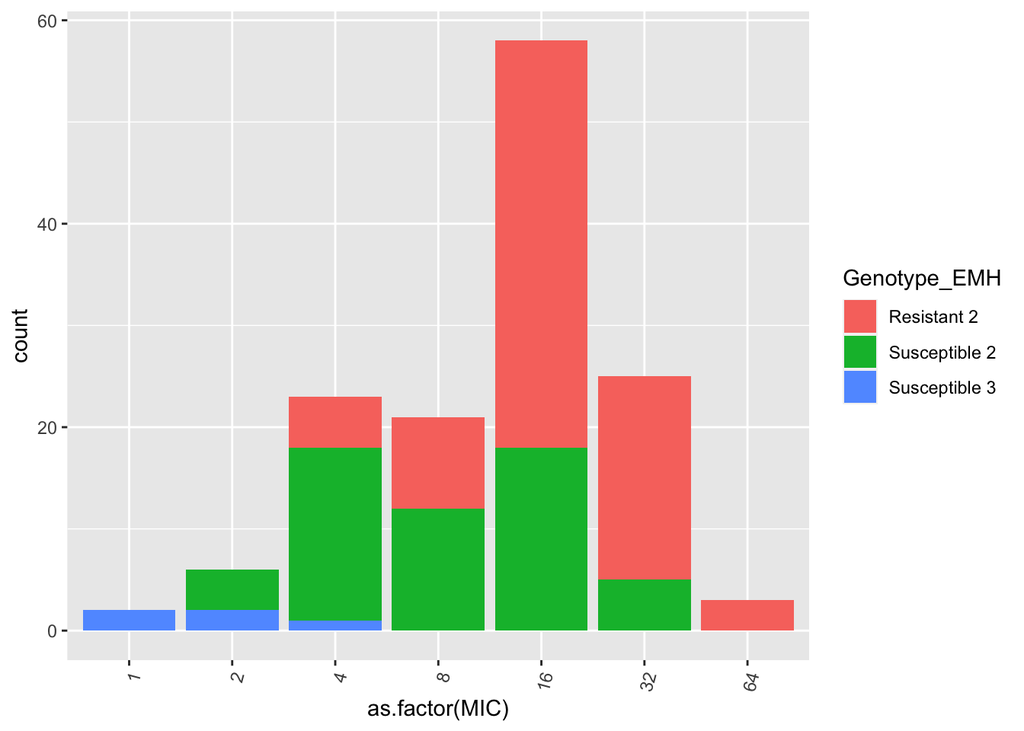

```
##   k split   cut.off WT NWT       N.mis
## 1 2     1 11.313708 52  86 30.67218059
## 2 3     1  2.828427  8 130  0.08113453
## 3 3     2  5.656854 31 107  1.48741637
```

Proposed ECOFF for Amoxicillin: 5.66.

- The 31 isolates with MIC $\leq 4$ are labelled “susceptible”.
- The 107 isolates with MIC $\geq 8$ are labelled “resistant”.

Predicted distribution of susceptible (S) and resistant (R) isolates from the model, with actual data shown in grey:

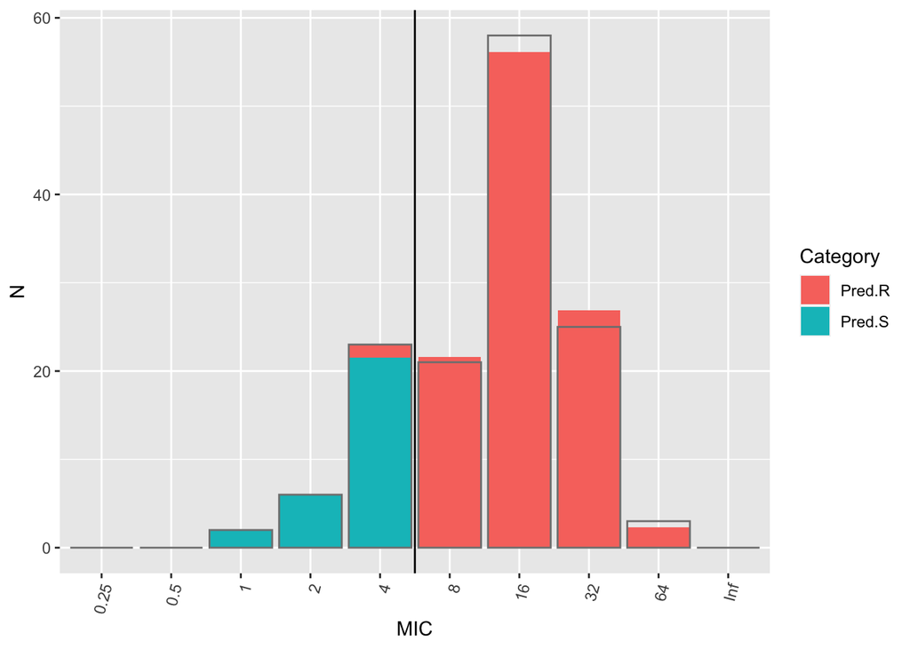

## Penicillin

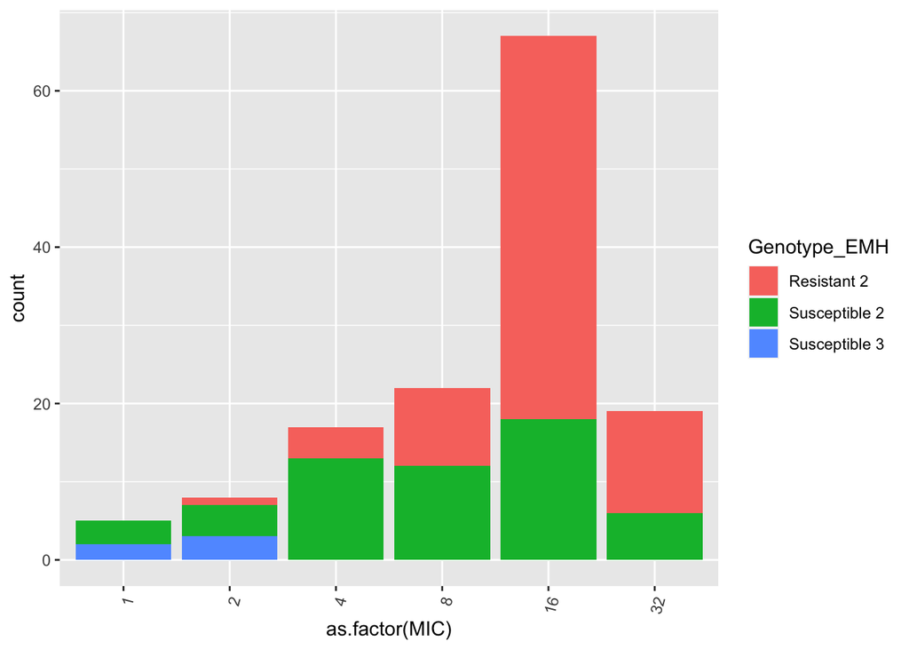

```
##   k split   cut.off WT NWT     N.mis
## 1 2     1 11.313708 52  86 14.690075
## 2 3     1  2.828427 13 125  2.559231
## 3 3     2 11.313708 52  86  5.812167
```

Proposed ECOFF for Penicillin: 11.31.

- The 52 isolates with MIC $\leq 8$ are labelled “susceptible”.
- The 86 isolates with MIC $\geq 16$ are labelled “resistant”.

Predicted distribution of susceptible (S) and resistant (R) isolates from the model, with actual data shown in grey:

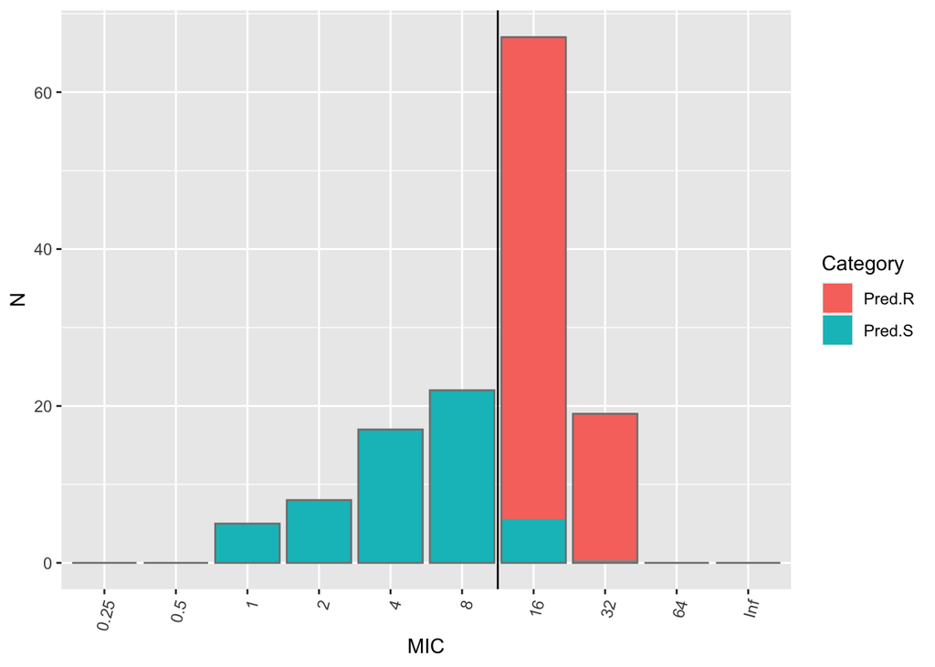

## Cefoxitin

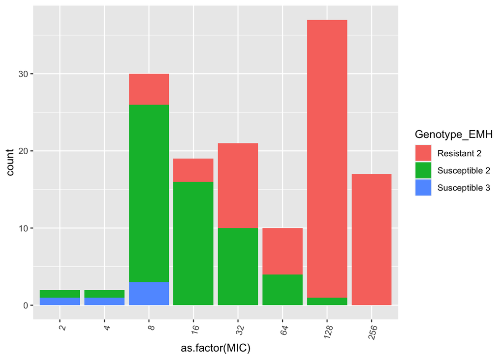

```
##   k split  cut.off WT NWT     N.mis
## 1 2     1 90.50967 84  54  3.983728
## 2 3     1 11.31371 34 104 15.324091
## 3 3     2 90.50967 84  54  4.118900
```

Proposed ECOFF for Cefoxitin: 90.5.

- The 84 isolates with MIC $\leq 64$ are labelled “susceptible”.
- The 54 isolates with MIC $\geq 128$ are labelled “resistant”.

Predicted distribution of susceptible (S) and resistant (R) isolates from the model, with actual data shown in grey:

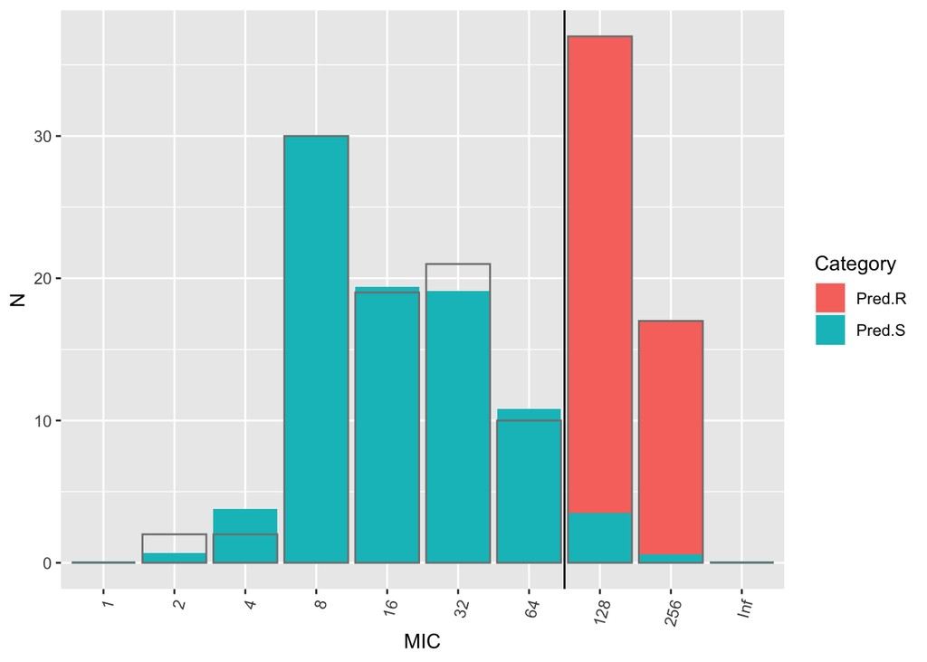

## Clavulanic Acid

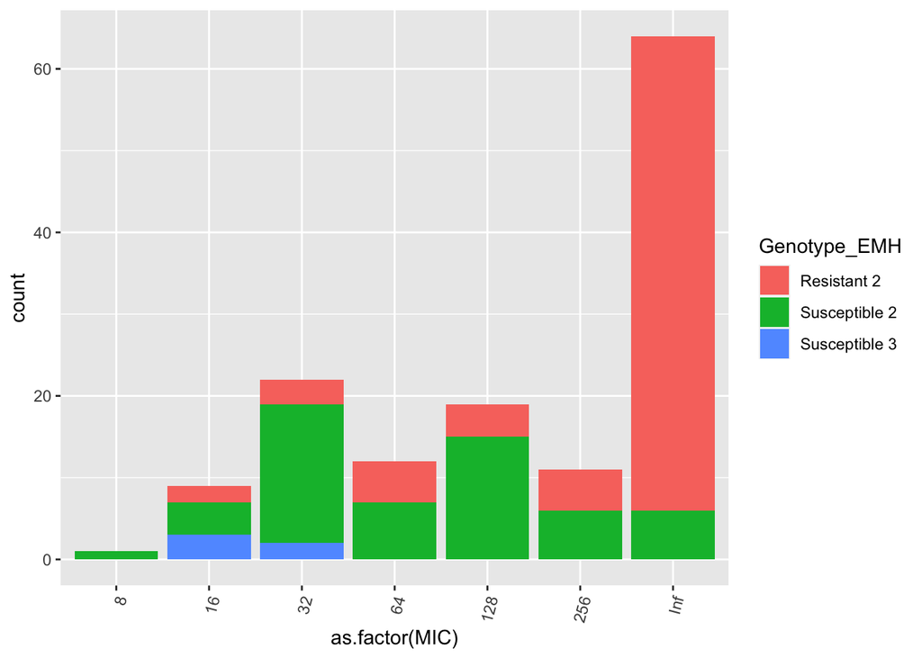

```
##   k split  cut.off WT NWT    N.mis
## 1 2     1 45.25483 32 106 11.26020
## 2 3     1 45.25483 32 106 12.94116
## 3 3     2 45.25483 32 106 12.43395
```

Proposed ECOFF for Clavulanic Acid: 45.2

- The 32 isolates with MIC $\leq 32$ are labelled “susceptible”.
- The 106 isolates with MIC $\geq 64$ are labelled “resistant”.

Predicted distribution of susceptible (S) and resistant (R) isolates from the model, with actual data shown in grey:

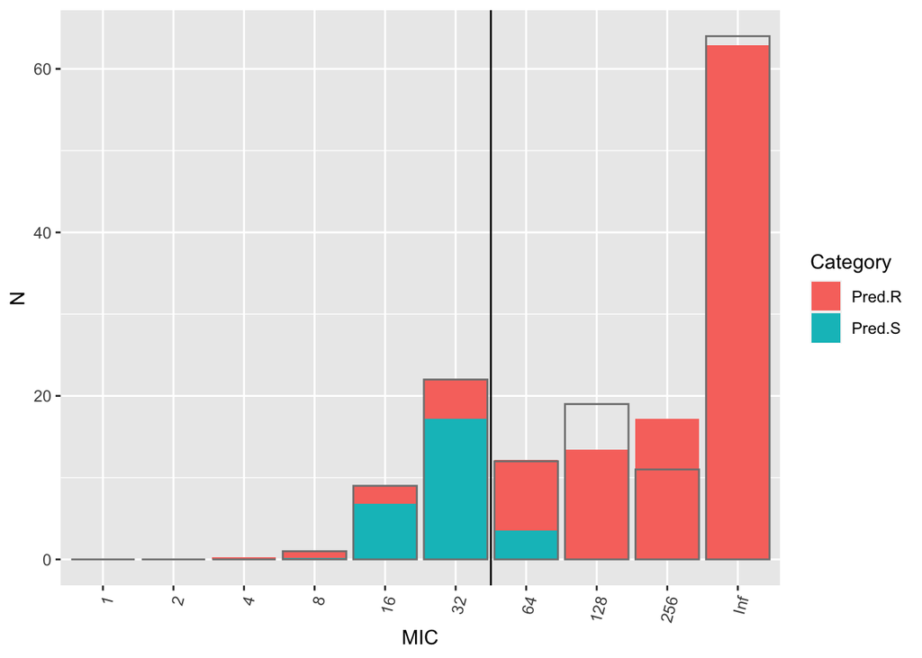